# Práctico 2

#### Gráficos

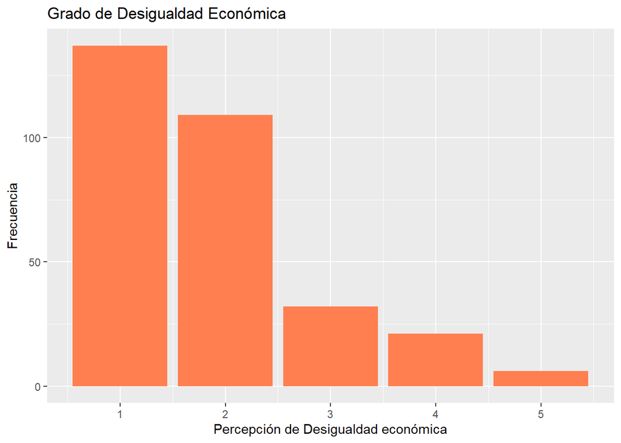

```r
Base_elsoc_fil %>% ggplot(aes(x = Ingresos)) +
  geom_bar(fill = "coral")+
  labs(title = "Grado de Desigualdad Económica",
       x = "Percepción de Desigualdad económica",
       y = "Frecuencia")
```

Por medio del primer gráfico correspondiente a la variable Ingresos, apreciamos que los resultados se concentran en las categoris 1 y 2 que representan una sensación de injusticia ante la situación de vida que presenta una persona de clase social alta en comparación a la una de clase social baja, superando ambas los 100 casos por categoria de respuesta.

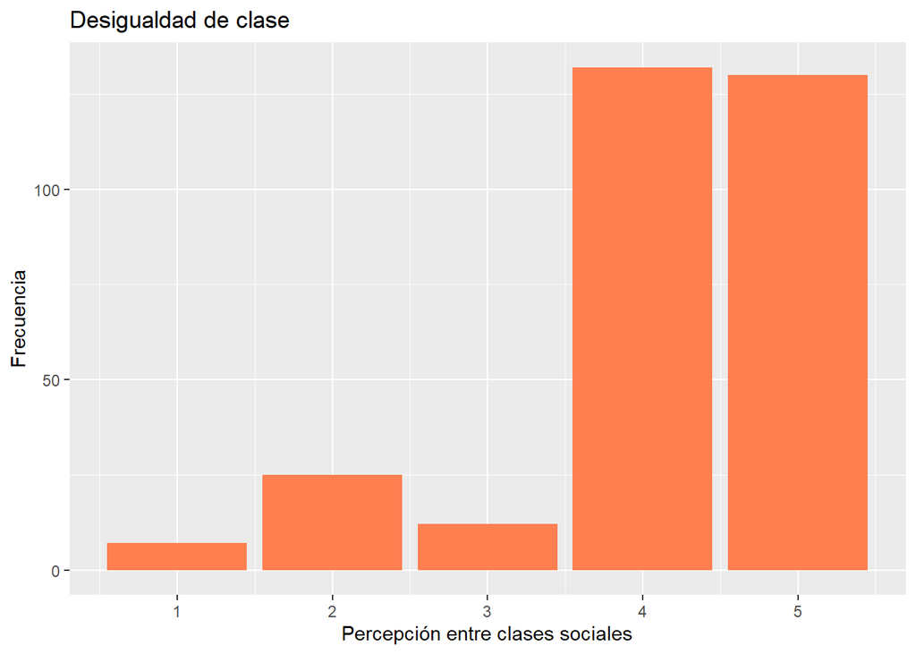

```r
Base_elsoc_fil %>% ggplot(aes(x = Desigualdad)) +
  geom_bar(fill = "coral")+
  labs(title = "Desigualdad de clase",
       x = "Percepción entre clases sociales",
       y = "Frecuencia")
```

Siguiendo la misma lógica, en la variable Desigualdad se encuentra una mayor concentración de respuestas en las categorias 4 y 5 las cuales índican un alto grado de acuerdo en que en Chile existen grandes diferencias de ingresos, una mayor desigualdad económica por parte de los jovenes de 18 a 25 años en el año 2016.

#### Tablas de contingencia

```r
sjt.xtab(Base_elsoc_fil$Ingresos, Base_elsoc_fil$Sexo)
```

| Justificacion de diferencias entre clases sociales | Sexo del entrevistado |  | Total |  |
| --- | --- | --- | --- | --- |
|  | Hombre | Mujer |  |  |
| Muy injusta | 59 | 78 |  | 137 |
| Injusta | 52 | 57 | 109 |  |
| Ni injusta ni justa | 12 | 20 | 32 |  |
| Justa | 9 | 12 | 21 |  |
| Muy justa | 3 | 3 | 6 |  |
| Total | 135 | 170 | 305 |  |

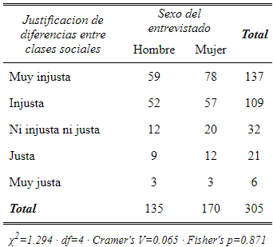

Por medio del cruzamiento de las variables Ingresos y Sexo para identificar la inclinación de cada sexo respecto al fenomeno, se puede establecer que no existe una diferencia sustancial entre los sexos respecto a la percepción de injusticia entre las clases sociales, donde un total de 246 personas aluden la presencia de esta problemática.

```r
sjt.xtab(Base_elsoc_fil$Sexo, Base_elsoc_fil$Desigualdad, encoding = "UTF-8")
```

| Sexo del entrevistado | Grado de acuerdo: Las diferencias de ingreso son demasiado grandes |  |  |  |  | Total |  |
| --- | --- | --- | --- | --- | --- | --- | --- |
|  | Totalmente de desacuerdo | Desacuerdo | Ni en desacuerdo ni de acuerdo | De acuerdo | Totalmente de acuerdo |  |  |
| Hombre | 2 | 8 | 4 | 61 | 60 |  | 135 |
| Mujer | 5 | 17 | 8 | 71 | 70 | 171 |  |
| Total | 7 | 25 | 12 | 132 | 130 | 306 |  |

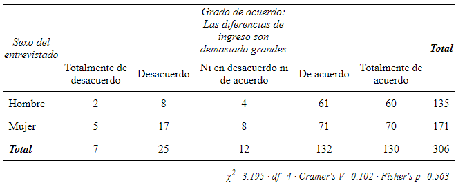

A partir de la segunda tabla de contingencia creada a partir del cruzamiento de las variables Desigualdad y Sexo, se puede identificar como nuevamente ambos sexos poseen una fuerte inclinación hacia un alto grado de acuerdo respecto a que en Chile hay grandes diferencias de ingresos económicos, evidenciando una gran percepción de desigualdad económica.

### Tabla con porcentajes

```r
sjt.xtab(Base_elsoc_fil$Ingresos, Base_elsoc_fil$Sexo,
         show.col.prc=TRUE,
         show.summary=FALSE,
         encoding = "UTF-8")
```

| Justificacion de diferencias entre clases sociales | Sexo del entrevistado |  | Total |  |
| --- | --- | --- | --- | --- |
|  | Hombre | Mujer |  |  |
| Muy injusta | 59 43.7 % | 78 45.9 % |  | 137 44.9 % |
| Injusta | 52 38.5 % | 57 33.5 % | 109 35.7 % |  |
| Ni injusta ni justa | 12 8.9 % | 20 11.8 % | 32 10.5 % |  |
| Justa | 9 6.7 % | 12 7.1 % | 21 6.9 % |  |
| Muy justa | 3 2.2 % | 3 1.8 % | 6 2 % |  |
| Total | 135 100 % | 170 100 % | 305 100 % |  |

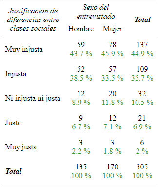

En esta etapa, las tablas de contingencia las transformamos a porcentajes para una mejor evaluación del analisis. En base a esto, hay un mayor porcentaje de mujeres que hombres los cuales índican una mayor presencia de injusticia entre las clases sociales. Mientras que, si sumamos las dos categorias de “Muy injusta” e”Injusta” resulta que los hombres obtienen mayor presencia. Por el contrario, las categorias de que las diferencias de vida entre clases es justa o muy justa tienen un porcentaje menor al 10% del total de los encuestados entre 18 y 25 años.

```r
sjt.xtab(Base_elsoc_fil$Desigualdad, Base_elsoc_fil$Sexo,
         show.col.prc=TRUE,
         show.summary=FALSE,
         encoding = "UTF-8")
```

| Grado de acuerdo: Las diferencias de ingreso son demasiado grandes | Sexo del entrevistado |  | Total |  |
| --- | --- | --- | --- | --- |
|  | Hombre | Mujer |  |  |
| Totalmente de desacuerdo | 2 1.5 % | 5 2.9 % |  | 7 2.3 % |
| Desacuerdo | 8 5.9 % | 17 9.9 % | 25 8.2 % |  |
| Ni en desacuerdo ni de acuerdo | 4 3 % | 8 4.7 % | 12 3.9 % |  |
| De acuerdo | 61 45.2 % | 71 41.5 % | 132 43.1 % |  |
| Totalmente de acuerdo | 60 44.4 % | 70 40.9 % | 130 42.5 % |  |
| Total | 135 100 % | 171 100 % | 306 100 % |  |

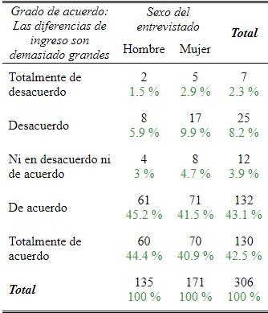

Por otra parte, a través de la tabla de frecuencia porcentual entre para ambos sexos hay una presencia de más de un 80% de acuerdo en torno a que en Chile las diferencias de ingreso son demasiado grandes.

```r
sjt.xtab(Base_elsoc_fil$Ingresos, Base_elsoc_fil$Edad,
         show.col.prc=TRUE,
         show.summary=FALSE,
         encoding = "UTF-8")
```

| Justificacion de diferencias entre clases sociales | Sexo Encuestados |  |  |  |  |  |  |  | Total |  |
| --- | --- | --- | --- | --- | --- | --- | --- | --- | --- | --- |
|  | 18 | 19 | 20 | 21 | 22 | 23 | 24 | 25 |  |  |
| Muy injusta | 7 36.8 % | 18 56.2 % | 12 46.2 % | 11 28.2 % | 21 42.9 % | 18 40.9 % | 22 43.1 % | 28 62.2 % |  | 137 44.9 % |
| Injusta | 7 36.8 % | 10 31.2 % | 6 23.1 % | 19 48.7 % | 16 32.7 % | 18 40.9 % | 19 37.3 % | 14 31.1 % | 109 35.7 % |  |
| Ni injusta ni justa | 4 21.1 % | 2 6.2 % | 3 11.5 % | 5 12.8 % | 4 8.2 % | 5 11.4 % | 7 13.7 % | 2 4.4 % | 32 10.5 % |  |
| Justa | 0 0 % | 2 6.2 % | 4 15.4 % | 2 5.1 % | 8 16.3 % | 2 4.5 % | 2 3.9 % | 1 2.2 % | 21 6.9 % |  |
| Muy justa | 1 5.3 % | 0 0 % | 1 3.8 % | 2 5.1 % | 0 0 % | 1 2.3 % | 1 2 % | 0 0 % | 6 2 % |  |
| Total | 19 100 % | 32 100 % | 26 100 % | 39 100 % | 49 100 % | 44 100 % | 51 100 % | 45 100 % | 305 100 % |  |

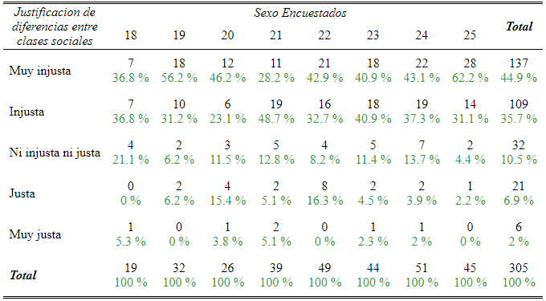

#### Conclusiones

En base a lo anterior y los datos entregados por la Encuesta ELSOC del año 2016 elaborada por el COES logramos identificar que en la población existe una alta percepción de desigualdad y de diferencia de vida entre las clases sociales. Identificando patrones de respuesta parecidos entre los encuestados pese a que sean de distintos sexos.

Mientras que, se logró demostrar que dentro de la encuesta, los casos más jovenes demuestran que hay una gran presencia de desigualdad entre las clases sociales, además de que proponen que las vidas de estos son de manera dispareja.

Esto avala que en nuestro país sea evaluado como uno de los más desiguales de latinoamerica, constando que la mayor cantidad de ingresos que recaen en el país son distribuidos en forma de disparidad.